# Welcome to my world

2017-10-31T22:42:51-05:00

# *My Childhood*

Hello, I am Mehak Khanna. I was born and raised in India. I currently live in London, United Kingdom. I have lived across various cities in North and Western parts of India including Amritsar, Ahmedabad, Mumbai. Chandigarh, also known as “The City Beautiful” is my current Indian home.

[figure not shown]

Chandigarh is one of the earliest planned cities in post-independence India and is internationally known for its architecture and urban design. The master plan of the city was prepared by Swiss-French architect Le Corbusier, which built upon earlier plans created by the Polish architect Maciej Nowicki and the American planner Albert Mayer. Most of the government buildings and housing in the city were designed by a team headed by Le Corbusier, Jane Drew and Maxwell Fry. Chandigarh’s Capitol Complex—as part of a global ensemble of Corbusier’s buildings—was declared a World Heritage Site by UNESCO at the 40th session of the World Heritage Conference in July 2016.

I love the city for its calm environment and the ease of commute which lets me stay connected with all my friends and family around.

[figure not shown]

My favorite spot in Chandigarh: Rock Garden

# *Education*

I have studied Bachelors in Technology at Punjab Engineering College, Chandigarh. During the course of my degree, I discovered my passion for data and grabbed a job at ZS Associates as a Business Technology Solutions Associate. Post an amazing year at ZS Associates, I joined McKinsey and Company as a Junior analyst, and progressed to the role of an Analyst within a short span of 10 months.

[figure not shown]

Attraction at PEC Chandigarh: Air Force Helicoptor

I am currently reading for Masters in Analytics and Management at London Business School and am aiming to pursue a career in consulting post my course at LBS.

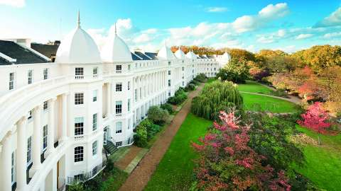

My Favorite spot at London Business school

# *Professional experiences*

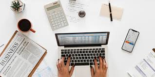

During the course of my degree, I discovered my passion for data and grabbed a job at ZS Associates as a Business Technology Solutions Associate. Post an amazing year at ZS Associates, I joined McKinsey and Company as a Junior analyst, and progressed to the role of an Analyst within a short span of 10 months.

My experience of working with McKinsey & Company and ZS Associates has led to my evolution as a critical thinker, collaborative and curious individual. Working in a dynamic environment has nurtured my appetite for risk-taking, ability to deal with complex indeterminate problems and navigate through ambiguity un-flustered. As a technology analyst at ZS Associates, I worked on projects ranging from process optimization, technology transformation and designing growth strategies for clients across pharmaceutical and healthcare industry. As an Analyst at McKinsey and Company, I worked on pricing analytics (growth strategy, forecasting) to uncover consumer behaviour and curate marketing strategies for clients.

[figure not shown]

# *Interests*

In addition to my professional experience, I am an enthusiastic traveller and have been to over 25+ cities across 3 continents. My source of adrenal rush includes trying roller coasters around these cities and I have covered over 30+ roller coasters including the world’s fastest and steepest ones

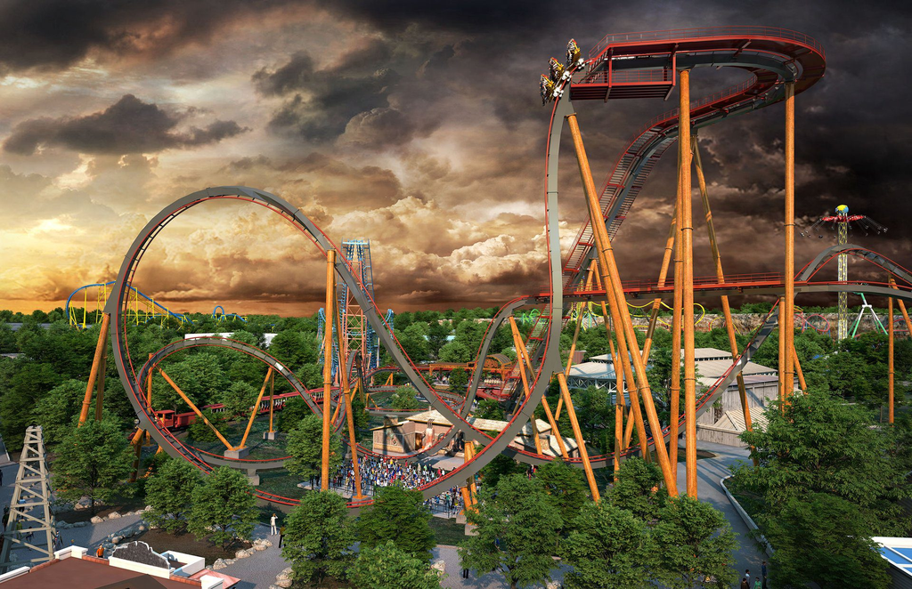

My favorite park: Six Flags

# *My life at London Business School*

I have started my journey at LBS few weeks back and am enjoying every moment of it. Excited to see what the future holds.

Thanks for visiting!!